# Forecasting with SARIMA: example 2

Maria Eduarda Silva

LMU, July 1 2022

# Forecasting Total Private Residential Construction Spending

## Introduction

Having build models for the monthly Total Private Residential Construction Spending data we now study their forecasting performance.

```r
library(astsa)
library(xts)
library(zoo)
library(forecast)
library(Quandl)
Quandl.api_key("XzdSwkDsE98Mxj3ixQzG")
# Total Private Residential Construction Spending : FRED/PRRESCON
```

## Data

Data for this model are imported from Quandl website (FRED/PRRESCON).

```r
prc <- Quandl("FRED/PRRESCON", type = "zoo")
y=prc
```

```r
yall<-window(y, end=2016+11/12)
fstM <- 1993+0/12
lstM <- 2013+11/12
y1 <- window(yall, end=lstM)
ly <- log(y1)
y2 <- window(yall, start=lstM+1/12)
```

Previously we have obtained 3 models that are adequate to the time series (training set). The residuals are uncorrelated and all the parameters statistically significant. Model m2 explains the serial correlation very well but some parameters are not statistically significant; model m21 has all the parameters statistically significant but there is a bit of serial correlation that remain unexplained. Model o11 has an AR(1) how close to the non-stationarity region The coefficient for the seasonal AR component of model o11 is quite close to non-stationarity .

| Model | Order | N Par | AIC | AICc | BIC |
| --- | --- | --- | --- | --- | --- |
| m2 | $(3,1,9)\times(1,1,1)_{12}$ | 14 | -1241.71 | -1239.55 | -1189.56 |
| m21 | $(3,1,9)\times(1,1,1)_{12}$ | 14-3 | -1238.58 | -1237.79 | -1207.29 |
| o11 | $(9,1,0)\times(1,0,0)_{12}$ | 10-4 | -1264 | -1263.4 | -1235.8 |

and therefore o11 has lower information criteria.

```r
m2=Arima(ly, order = c(3,1,9), seasonal=list(order=c(1,1,1), period=12))
m21=Arima(ly, order = c(3,1,9), seasonal=list(order=c(1,1,1), period=12), fixed=c(NA, NA, NA, NA, NA, NA, 0, NA, 0, 0, NA, NA, NA, NA))
o11=Arima(ly, order = c(9,1,0), seasonal=list(order=c(1,0,0), period=12), fixed=c(NA,NA, 0,0,0,0,NA,NA,NA,NA))
```

We now study their performance in the test set. First we construct forecasts for the next 36 months, spanning January 2014 to December 2016.

```r
# construct 36 month ahead forecasts
hmax <-36
m2.f.h <- forecast(m2, h=hmax)
m21.f.h <- forecast(m21, h=hmax)
o11.f.h <- forecast(o11, h=hmax)
str(m2.f.h)
```

```
## List of 10
##  $ method   : chr "ARIMA(3,1,9)(1,1,1)[12]"
##  $ model    :List of 18
##   ..$ coef     : Named num [1:14] 0.88 0.517 -0.717 -0.492 -0.46 ...
##   .. ..- attr(*, "names")= chr [1:14] "ar1" "ar2" "ar3" "ma1" ...
##   ..$ sigma2   : num 0.000305
##   ..$ var.coef : num [1:14, 1:14] 0.01548 -0.02004 0.00961 -0.01532 0.01314 ...
##   .. ..- attr(*, "dimnames")=List of 2
##   .. .. ..$ : chr [1:14] "ar1" "ar2" "ar3" "ma1" ...
##   .. .. ..$ : chr [1:14] "ar1" "ar2" "ar3" "ma1" ...
##   ..$ mask     : logi [1:14] TRUE TRUE TRUE TRUE TRUE TRUE ...
##   ..$ loglik   : num 636
##   ..$ aic      : num -1242
##   ..$ arma     : int [1:7] 3 9 1 1 12 1 1
##   ..$ residuals: Time-Series [1:252] from 1993 to 2014: 0.00549 0.00238 0.00168 0.00135 0.00117 ...
##   ..$ call     : language Arima(y = ly, order = c(3, 1, 9), seasonal = list(order = c(1, 1, 1), period = 12))
##   ..$ series   : chr "ly"
##   ..$ code     : int 0
##   ..$ n.cond   : int 0
##   ..$ nobs     : int 239
##   ..$ model    :List of 10
##   .. ..$ phi  : num [1:15] 0.88 0.517 -0.717 0 0 ...
##   .. ..$ theta: num [1:21] -0.4923 -0.4595 0.404 0.0466 0.2205 ...
##   .. ..$ Delta: num [1:13] 1 0 0 0 0 0 0 0 0 0 ...
##   .. ..$ Z    : num [1:35] 1 0 0 0 0 0 0 0 0 0 ...
##   .. ..$ a    : num [1:35] 0.01623 0.00655 -0.0123 0.00594 0.00638 ...
##   .. ..$ P    : num [1:35, 1:35] -3.84e-14 1.84e-14 1.98e-14 -1.54e-14 -2.60e-15 ...
##   .. ..$ T    : num [1:35, 1:35] 0.88 0.517 -0.717 0 0 ...
##   .. ..$ V    : num [1:35, 1:35] 1 -0.4923 -0.4595 0.404 0.0466 ...
##   .. ..$ h    : num 0
##   .. ..$ Pn   : num [1:35, 1:35] 1 -0.4923 -0.4595 0.404 0.0466 ...
##   ..$ aicc     : num -1240
##   ..$ bic      : num -1190
##   ..$ x        : Time-Series [1:252] from 1993 to 2014: 9.51 9.4 9.55 9.67 9.76 ...
##   ..$ fitted   : Time-Series [1:252] from 1993 to 2014: 9.5 9.4 9.55 9.66 9.76 ...
##   ..- attr(*, "class")= chr [1:3] "forecast_ARIMA" "ARIMA" "Arima"
##  $ level    : num [1:2] 80 95
##  $ mean     : Time-Series [1:36] from 2014 to 2017: 10.1 10.1 10.3 10.4 10.5 ...
##  $ lower    : Time-Series [1:36, 1:2] from 2014 to 2017: 10.1 10.1 10.3 10.4 10.4 ...
##   ..- attr(*, "dimnames")=List of 2
##   .. ..$ : NULL
##   .. ..$ : chr [1:2] "80%" "95%"
##  $ upper    : Time-Series [1:36, 1:2] from 2014 to 2017: 10.2 10.2 10.4 10.5 10.6 ...
##   ..- attr(*, "dimnames")=List of 2
##   .. ..$ : NULL
##   .. ..$ : chr [1:2] "80%" "95%"
##  $ x        : Time-Series [1:252] from 1993 to 2014: 9.51 9.4 9.55 9.67 9.76 ...
##  $ series   : chr "ly"
##  $ fitted   : Time-Series [1:252] from 1993 to 2014: 9.5 9.4 9.55 9.66 9.76 ...
##  $ residuals: Time-Series [1:252] from 1993 to 2014: 0.00549 0.00238 0.00168 0.00135 0.00117 ...
##  - attr(*, "class")= chr "forecast"
```

Forecast accuracy evaluation. Results for the the training set and test set are available. The results for the training set are obtained using the residuals.

```r
# evaluate forecast accuracy in the test set
m2.f.h.acc=accuracy(m2.f.h, log(y2))
m21.f.h.acc=accuracy(m21.f.h, log(y2),d=0,D=1)
o11.f.h.acc=accuracy(o11.f.h, log(y2),d=0,D=1)
m2.f.h.acc
```

```
##                         ME       RMSE        MAE          MPE      MAPE
## Training set  2.254478e-05 0.01650593 0.01281297  0.000922936 0.1254084
## Test set     -2.528088e-01 0.28118037 0.25280880 -2.399146465 2.3991465
##                    MASE       ACF1
## Training set 0.09880679 0.01792846
## Test set     1.94952682         NA
```

```r
m21.f.h.acc
```

```
##                        ME       RMSE        MAE          MPE      MAPE
## Training set  2.55766e-05 0.01661892 0.01288458  0.000965367 0.1260931
## Test set     -2.52676e-01 0.28072983 0.25267600 -2.397980750 2.3979808
##                    MASE      ACF1
## Training set 0.09935903 0.0465615
## Test set     1.94850269        NA
```

```r
o11.f.h.acc
```

```
##                         ME       RMSE        MAE          MPE      MAPE
## Training set  0.0002366901 0.01754826 0.01368651  0.003110016 0.1342624
## Test set     -0.1826813940 0.20203986 0.18268139 -1.734794473 1.7347945
##                  MASE       ACF1
## Training set 0.105543 0.01303952
## Test set     1.408742         NA
```

Training set

[output not shown]

Test set

[output not shown]

In the test set model it is also model o11 that presents the best accuracy measures with a MAPE of 1.7%.

You can access the confidence intervals in the forecast object: 95% CI

```r
m2.f.h$lower [1:12,2]
```

```
##  [1] 10.10140 10.08761 10.23995 10.32808 10.38703 10.43110 10.44589 10.44649
##  [9] 10.40853 10.41410 10.27884 10.15896
```

```r
m2.f.h$upper [,2]
```

```
##           Jan      Feb      Mar      Apr      May      Jun      Jul      Aug
## 2014 10.16988 10.20474 10.40932 10.54699 10.65313 10.74495 10.80782 10.85241
## 2015 10.68592 10.71063 10.91110 11.04551 11.15352 11.25184 11.32617 11.38344
## 2016 11.26289 11.29554 11.50265 11.64537 11.76225 11.86750 11.94758 12.01085
##           Sep      Oct      Nov      Dec
## 2014 10.86040 10.90556 10.80707 10.71724
## 2015 11.40101 11.45445 11.36569 11.28631
## 2016 12.03705 12.09996 12.01889 11.94544
```

The plot function when applied to an forecast object plots the confidence intervals. Now plot the forecasts and confidence intervals. We add the observed values- black line.

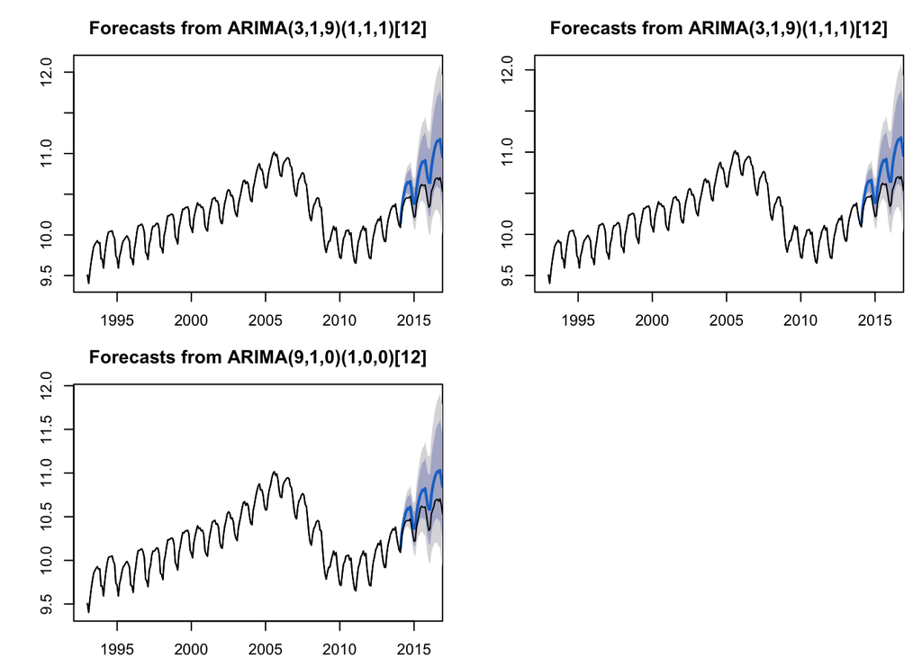

```r
# Plot forecast
par(mfrow=c(2,2), cex=0.7, mar=c(2,4,3,1))
plot(m2.f.h, xlim=c(1993,2016))
lines(log(yall))
plot(m21.f.h, xlim=c(1993,2016))
lines(log(yall))
plot(o11.f.h, xlim=c(1993,2016))
lines(log(yall))
```

We conclude that all the models produce forecasts that overestimate the observed values. We can study in further detail how the models perform.

The following plots allow to look to the forecasts with more detail.

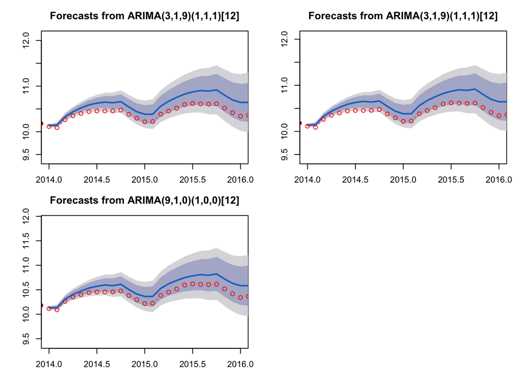

```r
par(mfrow=c(2,2), cex=0.7, mar=c(2,4,3,1))
plot(m2.f.h, xlim=c(2014,2016),type="b")
lines(log(yall),type ="b", col= "red")
plot(m21.f.h, xlim=c(2014,2016),type="b")
lines(log(yall),type ="b", col= "red")
plot(o11.f.h, xlim=c(2014,2016),type="b")
lines(log(yall),type ="b", col= "red")
```

An important question is whether the observed values are in fact covered by the confidence intervals. Also we like to know if the errors, e.g. , percentage errors vary systematically in time or with month. We can also make tables and compute percentage errors for each step-ahead.

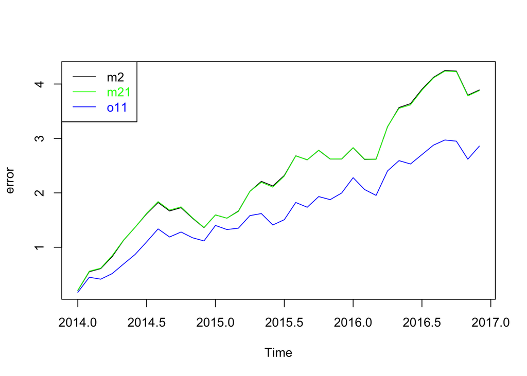

```r
error.m2= abs(as.vector(log(y2))-m2.f.h$mean)/m2.f.h$mean*100
error.m21= abs(as.vector(log(y2))-m21.f.h$mean)/m2.f.h$mean*100
error.o11= abs(as.vector(log(y2))-o11.f.h$mean)/m2.f.h$mean*100
plot(error.m2, ylab="error")
lines(error.m21,col="green")
lines(error.o11,col="blue")
legend("topleft", legend=c("m2","m21","o11"),lty=c(1,1,1), text.col=c("black","green","blue"), col=c("black","green","blue"))
```

Note that the forecast errors grow with the number of steps ahead that we are forecasting. Next we compare 1 month ahead rolling forecasts for the 3 models.

```r
# construct 1 month ahead rolling forecasts from model m4, together with their confidence intervals
m2.f.rol <- list()
m21.f.rol <- list()
o11.f.rol <- list()
for(i in 1:(length(y2)+1))
{
  y <- window(yall, start=fstM+(i-1)/12, end=lstM+(i-1)/12 )
  ly <- log(y)
  m2.updt <- Arima(ly, order = c(3,1,9), seasonal=list(order=c(1,1,1), period=12))
  m2.updt.f.1 <- forecast(m2.updt,1)
  m2.f.rol$mean <- rbind(m2.f.rol$mean, as.zoo(m2.updt.f.1$mean))
  m2.f.rol$lower <- rbind(m2.f.rol$lower, m2.updt.f.1$lower)
  m2.f.rol$upper <- rbind(m2.f.rol$upper, m2.updt.f.1$upper)

  m21.updt <- Arima(ly, order = c(3,1,9), seasonal=list(order=c(1,1,1), period=12), fixed=c(NA, NA, NA, NA, NA, NA, 0, NA, 0, 0, NA, NA, NA, NA))
  m21.updt.f.1 <- forecast(m21.updt,1)
  m21.f.rol$mean <- rbind(m21.f.rol$mean, as.zoo(m21.updt.f.1$mean))
  m21.f.rol$lower <- rbind(m21.f.rol$lower, m21.updt.f.1$lower)
  m21.f.rol$upper <- rbind(m21.f.rol$upper, m21.updt.f.1$upper)

  o11.updt <- Arima(ly, order = c(9,1,0), seasonal=list(order=c(1,0,0), period=12), fixed=c(NA,NA, 0,0,0,0,NA,NA,NA,NA))
  o11.updt.f.1 <- forecast(o11.updt,1)
  o11.f.rol$mean <- rbind(o11.f.rol$mean, as.zoo(o11.updt.f.1$mean))
  o11.f.rol$lower <- rbind(o11.f.rol$lower, o11.updt.f.1$lower)
  o11.f.rol$upper <- rbind(o11.f.rol$upper, o11.updt.f.1$upper)
}
m2.f.rol$mean <- as.ts(m2.f.rol$mean)
m2.f.rol$level <- m2.updt.f.1$level
m2.f.rol$x <- window(m2.updt.f.1$x, end=lstM)
class(m2.f.rol) <- class(m2.f.h)
m21.f.rol$mean <- as.ts(m21.f.rol$mean)
m21.f.rol$level <- m21.updt.f.1$level
m21.f.rol$x <- window(m21.updt.f.1$x, end=lstM)
class(m21.f.rol) <- class(m21.f.h)

o11.f.rol$mean <- as.ts(o11.f.rol$mean)
o11.f.rol$level <- o11.updt.f.1$level
o11.f.rol$x <- window(o11.updt.f.1$x, end=lstM)
class(o11.f.rol) <- class(o11.f.h)
```

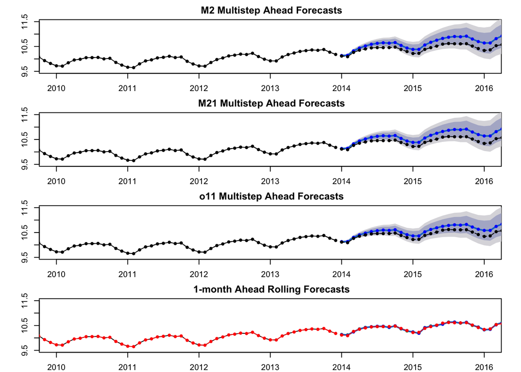

```r
par(mfrow=c(4,1), mar=c(2,4,2,2))

# plot multistep ahead forecasts
plot(m2.f.h, pch=20, xlim=c(2010,2016), ylim=c(9.5, 11.5), main=" M2 Multistep Ahead Forecasts")
lines(m2.f.h$mean, type="p", pch=20, lty="dashed", col="blue")
lines(log(yall), type="o", pch=20, lty="dashed")

plot(m21.f.h, pch=20, xlim=c(2010,2016), ylim=c(9.5, 11.5), main=" M21 Multistep Ahead Forecasts")
lines(m21.f.h$mean, type="p", pch=20, lty="dashed", col="blue")
lines(log(yall), type="o", pch=20, lty="dashed")

plot(o11.f.h, pch=20, xlim=c(2010,2016), ylim=c(9.5, 11.5), main=" o11 Multistep Ahead Forecasts")
lines(o11.f.h$mean, type="p", pch=20, lty="dashed", col="blue")
lines(log(yall), type="o", pch=20, lty="dashed")

# plot 1 step ahead rolling forecasts form model m2
plot(m2.f.rol, pch=20, xlim=c(2010,2016), ylim=c(9.5, 11.5), main=" 1-month Ahead Rolling Forecasts")
lines(m2.f.rol$mean, type="p", pch=20, lty="dashed", col="black")
lines(m21.f.rol$mean, type="p", pch=20, lty="dashed", col="green")
lines(o11.f.rol$mean, type="p", pch=20, lty="dashed", col="blue")
lines(log(yall), type="o", pch=20, lty="dashed", col="red")
```

```r
# evaluate forecast accuracy

accuracy(m2.f.rol$mean, log(y2))
```

```
##                    ME       RMSE        MAE         MPE      MAPE
## Test set -0.001404005 0.02034473 0.01736547 -0.01373382 0.1660694
```

```r
accuracy(m21.f.rol$mean, log(y2))
```

```
##                    ME       RMSE        MAE         MPE      MAPE
## Test set -0.001232738 0.02050834 0.01722529 -0.01231062 0.1645638
```

```r
accuracy(o11.f.rol$mean, log(y2))
```

```
##                    ME       RMSE        MAE        MPE      MAPE
## Test set -0.001437314 0.01937633 0.01668242 -0.0139762 0.1593236
```

When we forecast 1-step-ahead the all the models perform similarly.

These are forecasts for the log of the spending data. Now revert the log transformation (look in the slides or Hyndman book) and compare the 3 models.